# Wright-Fisher Simulation for genetic drift

Jinliang Yang

2025-01-30

# Wright-Fisher simulation

- Consider a single nucleotide position with two alleles, $A_1$ and $A_2$
- In generation $t$ there are $x$ individuals carrying allele $A_1$, which is at frequency $p_t = x/2N$.
- This implies that there are $2N - x$ individuals carrying allele $A_2$, which is at frequency $q_t = 1- p_t= 1- x/2N$.
- The sampling of alleles for the next generations is equivalent to sampling from a binomial distribution with parameters size = $2N$ and prob= $x/2N$.
- Therefore, the mean and variance of $p$ in the next generation for the Wright-Fisher model are:

$$\begin{align*}
E(p_{t+}) &= p_t \\
Var(p_{t+1}) &= p_tq_t/2N
\end{align*}$$

# Wright Fisher simulation

### First of all, let’s implement the Wright-Fisher simulation in R

```bash
cd ..
```

```r
# create a vector to store the allele count in each generation
x <- vector()
x[1] <- 1 # for example, a new mutation occurs in the first generation

# Start to loop over t generations
# binomial sampling at each generation - determines allele count in next generations
N <- 100 # number of diploid individuals
t = 10
for (i in 2:t){ # t is the number of generations, starting with generation 2
    # calculate allele freq in the current generation
    k <- (x[i-1])/(2*N)
    # generate a vector with 2N individuals
    n <- seq(0,2*N,1) # Creates a vector n containing all possible allele counts from 0 to 2N

    # density for the binomial distribution with paramters size=2N and prob=k
    prob <- dbinom(n, 2*N, k) # It returns a vector of probabilities corresponding to the likelihood of observing each allele count n given:
    # plot(prob)
    # choose one from a vector each with certain prob
    x[i] <- sample(0:(2*N), 1, prob=prob)
}
```

### let’s breakdown of the code `prob <- dbinom(n, 2*N, k)`

- The `dbinom` function computes the probability mass function (PMF) of a binomial distribution.

`n`: The number of successes (desired outcome). `2*N`: The number of trials (total number of attempts). `k`: The probability of success in each trial. `dbinom(n, size, prob)`: Returns the probability of exactly n successes in size trials, given success probability prob.

for example:

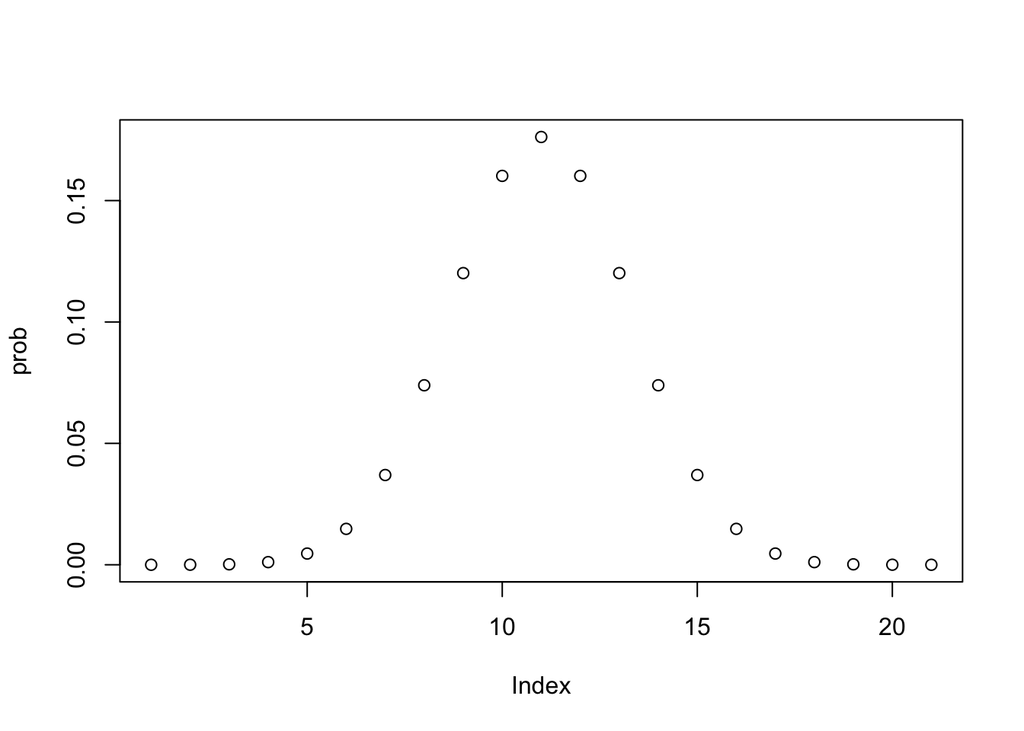

```r
n <- seq(0, 20, 1)
prob <- dbinom(n, 20, 0.5)
plot(prob)
```

This returns a vector where: - `prob[1]` is the probability of 0 copies. - `prob[11]` is the probability of 10 copies. - `prob[21]` is the probability of 20 copies. - The values follow a binomial distribution centered around 10, since k = 0.5.

### you can do this on your local computer!

```r
wright_fisher <- function(N=1000, t=100, A1=100){
  # N: number of diploid individuals. [N=1000, integer]
  # t: number of generations. [t=100, integer]
  # A1: number of A1 (the minor allele) in the first generation. [A1=10, integer]

  # create a vector
  x <- 0
  x[1] <- A1

  # Start to loop over m generations
  # binomial sampling at each generation - determines allele count in next generations
  for (i in 2:t){
    # calculate allele freq in the current generation
    k <- (x[i-1])/(2*N)
    # generate a vector with 2N individuals
    n <- seq(0,2*N,1)

    # density for the binomial distribution with paramters size=2N and prob=k
    prob <- dbinom(n, 2*N, k)
    # plot(prob)
    # choose one from a vector each with certain prob
    x[i] <- sample(0:(2*N), 1, prob=prob)
  }
  # return back the results
  return(x)
}
```

Here, we test a case of a new mutation occurs in the first generation of a small population

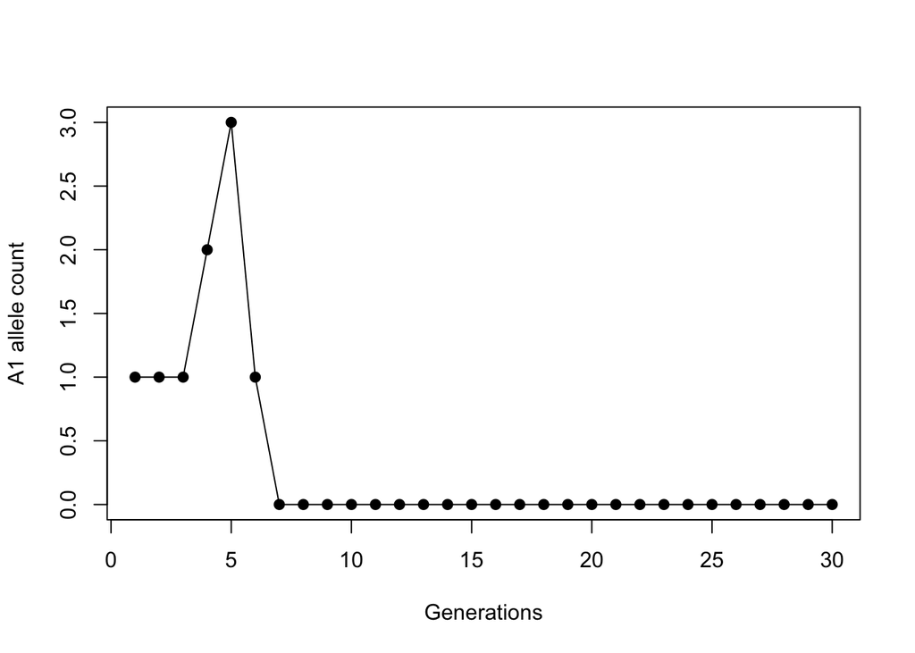

```r
sim1 <- wright_fisher(N=10, t=30, A1=1)
plot(sim1, type="o", pch=19, xlab="Generations", ylab="A1 allele count")
```

# simulate for one time

```r
set.seed(1234587)
sim1 <- wright_fisher(N=50, t=1000, A1=20)
plot(sim1[1:100], type="o", pch=19, xlab="Generations", ylab="A1 allele count")

sim1 <- wright_fisher(N=50, t=1000, A1=20)
plot(sim1[1:100], type="o", pch=19, xlab="Generations", ylab="A1 allele count")
```

[output not shown]

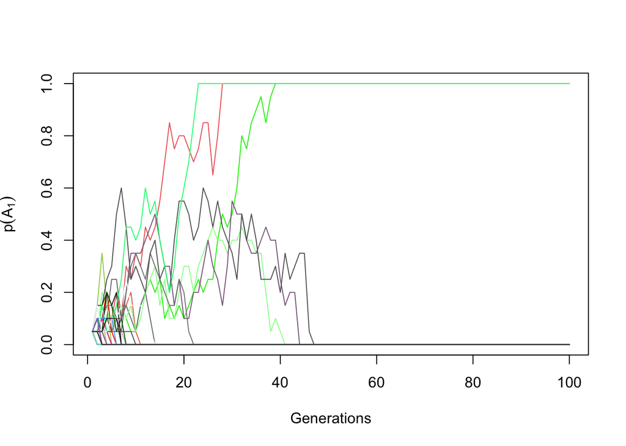

```r
set.seed(1234567)
n=10
a1=1
t=100
frq <- wright_fisher(N=n, A1=a1, t=t)/(2*n)
plot(frq, type="l", ylim=c(0,1), col=3, xlab="Generations", ylab=expression(p(A[1])))
    for(u in 1:100){
      frq <- wright_fisher(N=n, A1=a1, t=t)/(2*n)
      random <- sample(1:1000,1,replace=F)
      randomcolor <- colors()[random]
      lines(frq,type="l",col=(randomcolor))
    }
```